# Objetos espaciales en R

Susy Echeverría-Londoño

Investigadora asociada, Imperial College London

# 1 Pre-requisitos e instalación de paquetes

Lista de paquetes espaciales en R https://cran.r-project.org/web/views/Spatial.html

```r
install.packages(c("rgdal","rgeos", "maptools", "raster", "sp", "sf"))
```

Paquetes generales:

- maptools: manipulación de datos geográficos
- raster: Lectura, escritura, manipulación, análisis y modelamiento de datos espaciales en cuadrículas.
- sp: clases y métodos de datos espaciales (Pebesma & Bivand, 2018).
- rgdal: provee enlaces a la libreria geoespacial GDAL y acceso a las operaciones de proyección y transformación de la libreria PROJ4 (Bivand et al., 2017).
- sf: combinación estandarizada de funciones en sp, rgeos y rgdal para la manipulación de datos espaciales vectorizados (Pebesma, 2017)

## 1.1 Organización y creación de proyectos en R

[Guide to reproducible code (British Ecology Society)](https://www.britishecologicalsociety.org/wp-content/uploads/2017/12/guide-to-reproducible-code.pdf)

1. Crear un nuevo projecto en R
2. Crear carpetas básicas (e.g., ./data, ./figs, ./functions, …)

```
└── my_awesome_project
    ├── src
    ├── output
    ├── data
    │   ├── raw
    │   └── processed
    ├── README.md
    ├── run_analyses.R
    └── .gitignore
```

Fuente: https://www.r-bloggers.com/structuring-r-projects/

[figure not shown]

## 1.2 Ejercicio # 1:

- Crear un projecto de R
- Crear carpetas básicas para la práctica
- Abrir el projecto
- Crear un ‘R script’
- Crear etiquetas como `librerias` y `datos` dentro del script `(shortcut: Crtl+Shift+R)`

# 2 Representación simple de datos espaciales

## 2.1 Tipos básicos de R

- Números

`1 or 2 or 4000 or 10e9...`

- Cadenas (or characters)

`"Hola mundo"`

- Operadores lógicos

`"TRUE" or "FALSE"`

- Vectores

`c(1, 2) or c("uno", "dos")`

- Matrices

```r
matrix(data = c(c(1,2), c("Bucaramanga", "Bogotá")), nrow = 2, ncol = 2)
```

```
##      [,1] [,2]
## [1,] "1"  "Bucaramanga"
## [2,] "2"  "Bogotá"
```

- Data frames

```r
data.frame(Num = c(1,2), Nombre = c("Bucaramanga", "Bogotá"))
```

```
##   Num      Nombre
## 1   1 Bucaramanga
## 2   2      Bogotá
```

## 2.2 Puntos geográficos

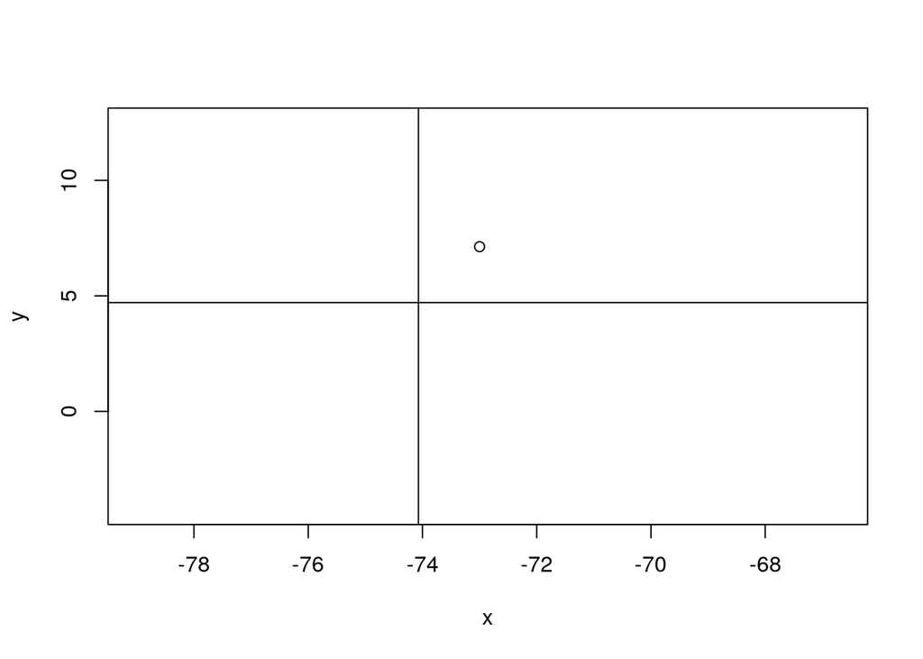

```r
x <- c(-73)
y <- c(7.13)

## Colombia continental
## Punta gallinas (lat= 12.46, lon = -71.67)
## Isla San José, Rio Negro Guainia Colombia (1.34, -66.7)
## Cabo Manglares (1.65, -79.01)
## Leticia (-4.23, -69.95)
plot(x, y, xlim = c(-79.01, -66.7), ylim = c(-4.23, 12.46))
# Bogotá
abline(h = 4.71, v = -74.07)
```

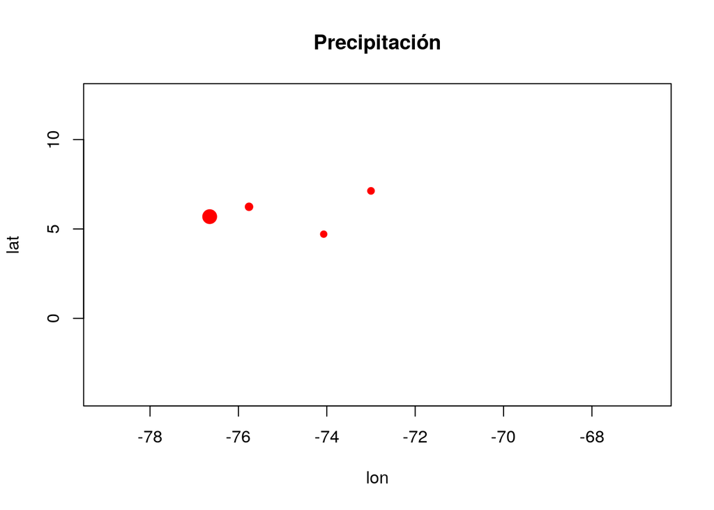

```r
## Quibdo 5.69, -76.65 (max 851.7 mm)
## Medellin 6.24, -75.76 (226.7 mm)
## Bogota 4.71, -74.07 (119 mm)
## Bucaramanga 7.13, -73 (149 mm)
lon = c(-76.65, -75.76, -74.07, -73)
lat = c(5.69, 6.24, 4.71, 7.13)
ciudades = cbind(lon, lat)
precip = c(852, 227, 119, 149)

psize <- 1 + precip/500
plot(ciudades, cex=psize, pch=20, col='red', main='Precipitación', xlim = c(-79.01, -66.7), ylim = c(-4.23, 12.46))
```

https://rstudio.com/wp-content/uploads/2015/03/ggplot2-cheatsheet.pdf

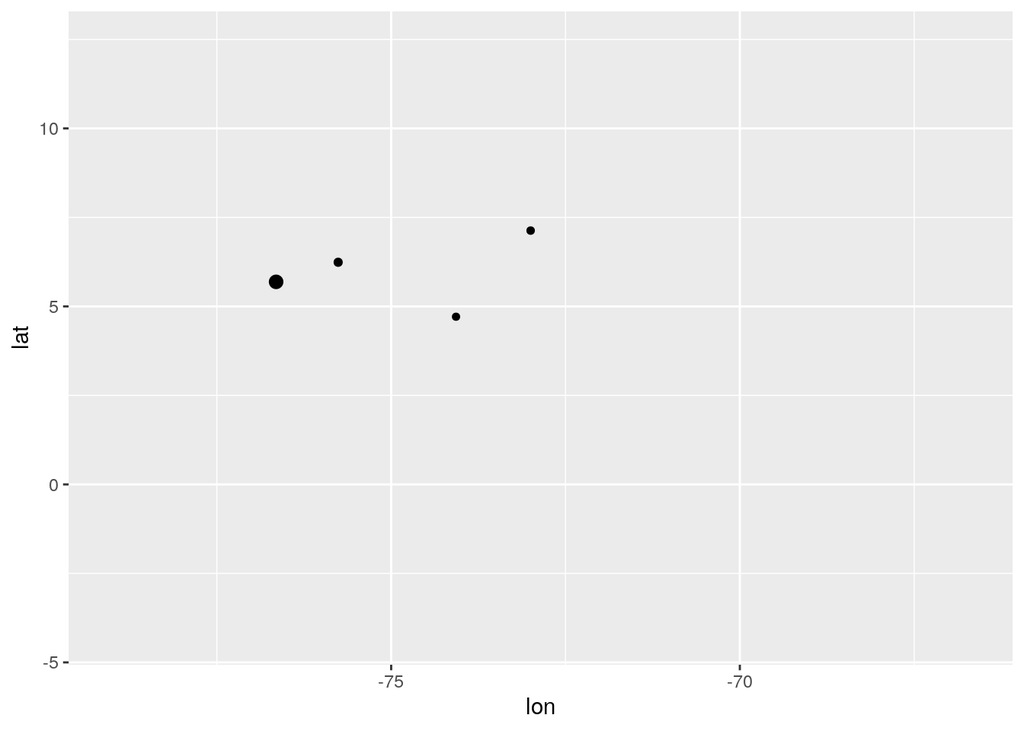

```r
library(tidyverse)
ciudades2 <- data.frame(x = lon, y = lat, precip = precip, nombre = c("Quibdo", "Medellín", "Bogotá", "Bucaramanga"))

ciudades2 %>%
ggplot(aes(x = lon, y = lat)) +
  geom_point(size = 1 + precip/500) +
  xlim(c(-79.01, -66.7)) +
  ylim(c(-4.23, 12.46))
```

# 3 Objetos espaciales

## 3.1 Vectores

### 3.1.1 Puntos geográficos

```r
library(sp)
library(mapview)
library(tmap)

ciudades_geo <- ciudades2
coordinates(ciudades_geo) <- ~x+y
```

```r
class(ciudades_geo)
```

```
## [1] "SpatialPointsDataFrame"
## attr(,"package")
## [1] "sp"
```

```r
ciudades_geo
```

```
## class       : SpatialPointsDataFrame
## features    : 4
## extent      : -76.65, -73, 4.71, 7.13  (xmin, xmax, ymin, ymax)
## crs         : NA
## variables   : 2
## names       : precip, nombre
## min values  :    119, Bogotá
## max values  :    852, Quibdo
```

```r
mapview(ciudades_geo, zcol = "nombre")
```

[interactive chart not shown]

## 3.2 Proyecciones y sistema de coordenadas

Forma en que los datos espaciales son “aplanados” en un espacio 2D

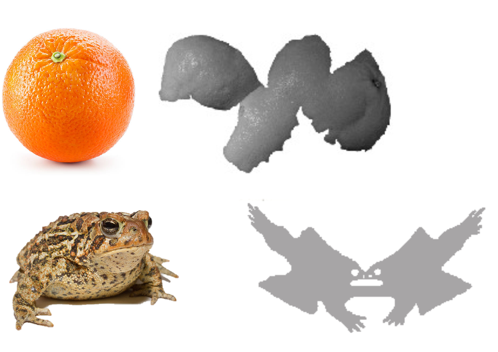

**“Alineación incorrecta de dos objetos espaciales = diferentes proyecciones”**

Fuente: National Ecological Observatory Network (NEON)

## 3.3 Extensión espacial

Coordenadas X y Y de las esquinas en el espacio geográfico

[figure not shown]

Fuente: National Ecological Observatory Network (NEON)

### 3.3.1 WGS84

```r
proj4string(ciudades_geo) <- "+proj=longlat +datum=WGS84"
mapview(ciudades_geo, zcol = "nombre")
```

[interactive chart not shown]

### 3.3.2 Cambiar la proyección de puntos geográficos

Lista de proyecciones disponibles

```r
rgdal:::projInfo()
```

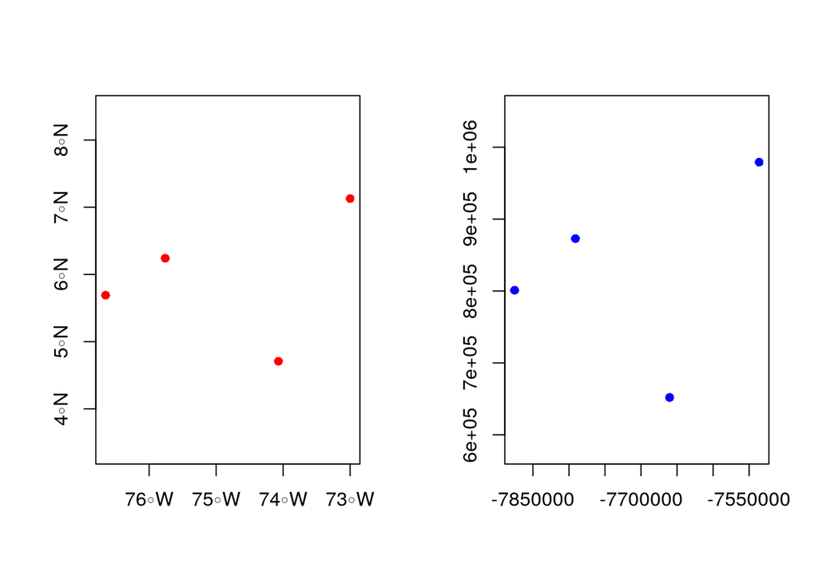

```r
## Lambert Azimuthal Equal Area
ciudades_geo2 <- spTransform(ciudades_geo, CRS("+proj=laea"))

par(mfrow = c(1,2))
plot(ciudades_geo, col = "red", pch = 16, axes = TRUE)
plot(ciudades_geo2, col = "blue", pch = 16, axes = TRUE)
```

## 3.4 Ejercicio #2:

- Busca en internet las coordenadas de 3 ciudades
- Crear un data frame con el nombre de la ciudad y las coordenadas
- Crear una gráfica de los puntos con los límites deseados usando plot o ggplot
- Convertir el data frame en `SpatialPointsDataFrame`
- Graficar los puntos con diferentes proyecciones geográficas

## 3.5 Poligonos

### 3.5.1 Con el paquete sp

```r
library(maptools)
data("wrld_simpl")

print(wrld_simpl)
```

```
## class       : SpatialPolygonsDataFrame
## features    : 246
## extent      : -180, 180, -90, 83.57027  (xmin, xmax, ymin, ymax)
## crs         : +proj=longlat +ellps=WGS84 +datum=WGS84 +no_defs +towgs84=0,0,0
## variables   : 11
## names       : FIPS, ISO2, ISO3,  UN,           NAME,    AREA,    POP2005, REGION, SUBREGION,      LON,     LAT
## min values  :     ,   AD,  ABW,   4, Aaland Islands,       0,          0,      0,         0, -178.131, -80.446
## max values  :   ZI,   ZW,  ZWE, 894,       Zimbabwe, 1638094, 1312978855,    150,       155,  179.219,   78.83
```

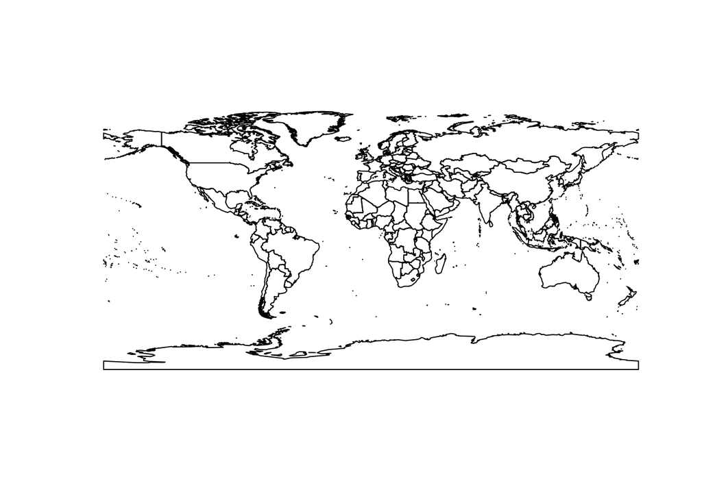

```r
plot(wrld_simpl)
```

#### 3.5.1.1 Filtrando los poligonos para solo Colombia

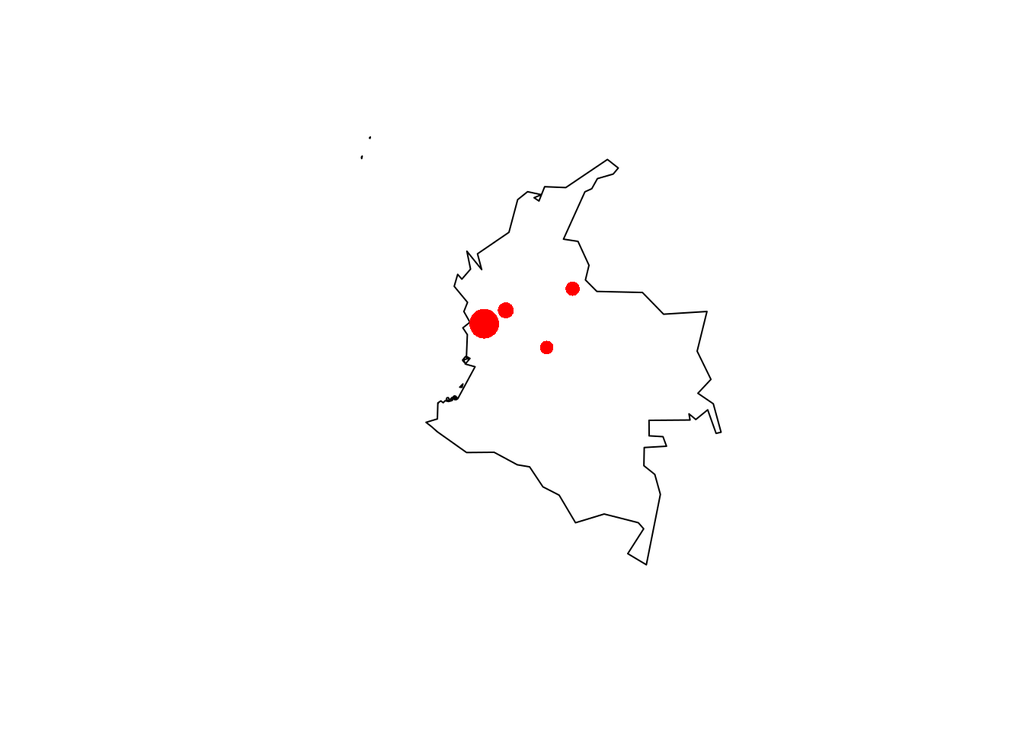

```r
Col_inx <- which(wrld_simpl$NAME == "Colombia")
Col_poly <- wrld_simpl[Col_inx,]

plot(Col_poly)
plot(ciudades_geo, add = TRUE, col = "red", cex = 1 + ciudades_geo$precip/500, pch = 16)
```

## 3.7 Include the map (vectors)

### 3.7.1 Usando el paquete “sf”

```r
library(sf)
## Quibdo 5.69, -76.65 (max 851.7 mm)
## Medellin 6.24, -75.76 (226.7 mm)
## Bogota 4.71, -74.07 (119 mm)
## Bucaramanga 7.13, -73 (149 mm)

# Coleccion de rasgos simples (Simple features collection, sfc)
# Crear varios sf
p1 <- st_point(c(5.69, -76.65))
p2 <- st_point(c(6.24,  -75.76))
p3 <- st_point(c(4.71, -74.07))
p4 <- st_point(c(7.13, -73))

# Juntar varios puntos en un sfc
ciudades_points <- st_sfc(p1, p2, p3, p4, crs = 4326)

ciudades_info <- data.frame(num = 1:nrow(ciudades2), nombre = c("Quibdo", "Medellín", "Bogotá", "Bucaramanga"), precip = ciudades2$precip)

ciudades_geo <- st_sf(ciudades_info, geometry = ciudades_points)
```

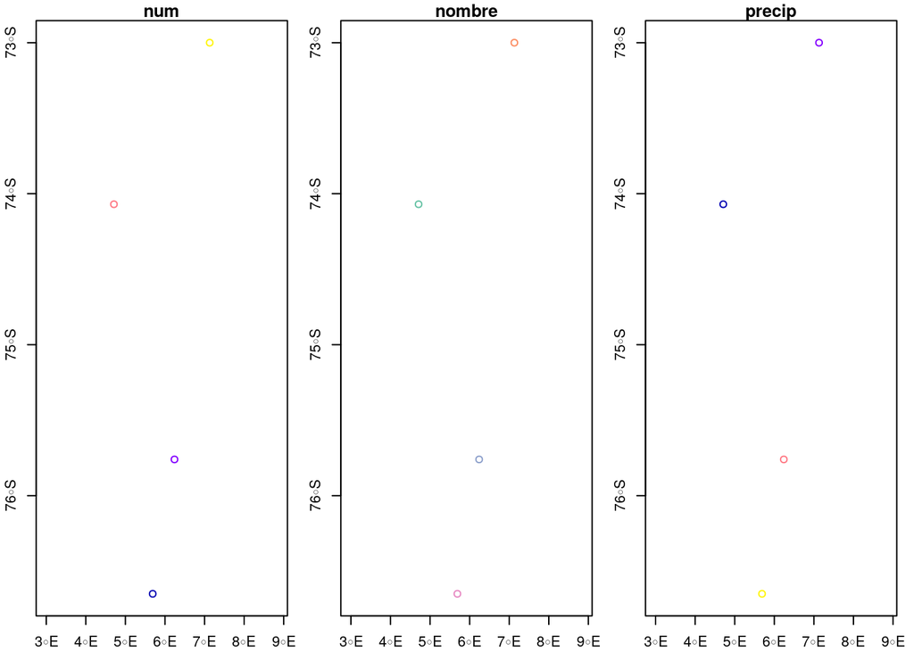

```r
plot(ciudades_geo, axes = TRUE)
```

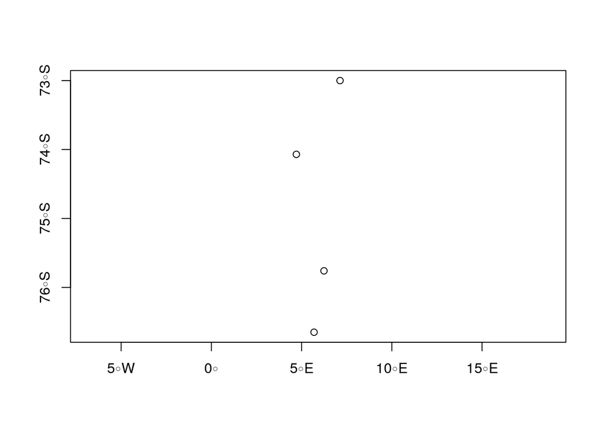

```r
plot(st_geometry(ciudades_geo), axes = TRUE)
```

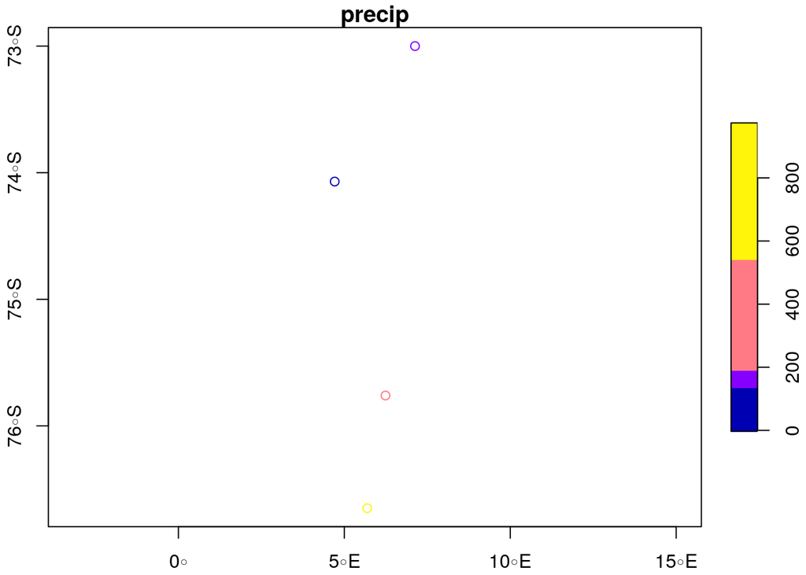

```r
plot(ciudades_geo["precip"], axes = TRUE, pwd = 16)
```

```r
ciudades_geo[ciudades_geo$nombre == "Quibdo",]
```

```
## Simple feature collection with 1 feature and 3 fields
## geometry type:  POINT
## dimension:      XY
## bbox:           xmin: 5.69 ymin: -76.65 xmax: 5.69 ymax: -76.65
## epsg (SRID):    4326
## proj4string:    +proj=longlat +datum=WGS84 +no_defs
##   num nombre precip            geometry
## 1   1 Quibdo    852 POINT (5.69 -76.65)
```

```r
plot(st_geometry(ciudades_geo[ciudades_geo$nombre == "Quibdo" | ciudades_geo$nombre == "Medellin" ,]))

ciudades_geo %>%
  filter(nombre == "Quibdo" | nombre == "Medellin") %>%
  st_geometry() %>%
  plot()
```

[output not shown]

```r
library(mapview)

mapview(ciudades_geo["nombre"])
```

[interactive chart not shown]

```r
mapview(ciudades_geo["precip"])
```

[interactive chart not shown]

### 3.7.2 Lineas

### 3.7.3 Polígonos

## 3.8 Rasters

- Datos espaciales en cuadrículas (“gridded data”)

## 3.9 Vectores

### 3.9.1 Puntos geográficos

### 3.9.2 Lineas

### 3.9.3 Polígonos

# 4 Objetos espaciales en R

## 4.1 Datos vectoriales

## 4.2 Datos raster